# gymnasts

2024-12-01

# Análisis Multicriterio de Competencias de Gimnasia 2022-2023

Este estudio se enfoca en evaluar el rendimiento de los países en competencias de gimnasia durante el período 2022-2023. Para ello, se utiliza un enfoque multicriterio basado en métodos como AHP, ELECTRE y PROMETHEE. El análisis considera criterios relevantes como los puntajes de dificultad, ejecución, penalizaciones, y la importancia de las rondas y competencias.

## Importación de datos

Los datos utilizados en este análisis se descargan de un repositorio público en formato CSV. Este conjunto incluye información detallada sobre las competencias, como los países participantes, los puntajes obtenidos y las características de cada evento.

```r
# Instalar y cargar las librerías necesarias
paquetes_necesarios <- c("dplyr", "tidyr", "formattable", "htmltools", "webshot")
paquetes_nuevos <- paquetes_necesarios[!(paquetes_necesarios %in% installed.packages()[, "Package"])]
if (length(paquetes_nuevos)) install.packages(paquetes_nuevos)

# Cargar las librerías
library(dplyr)
library(tidyr)
library(formattable)
library(htmltools)
library(webshot)


source("~/poli/TD/TDecisionCodigo/teoriadecision_funciones_multicriterio.R") #SOSTITUIR CON LA RUTA DEL ARCHIVO
```

```r
# Cargar las librerías necesarias
library(readr)
library(dplyr)

# Definir la URL del archivo CSV
url <- "https://raw.githubusercontent.com/ucsas/gym2024data/main/cleandata/data_2022_2023.csv"

# Descargar y leer el archivo CSV
datos_gimnasia <- read_csv(url)
datos_gimnasia <- data.frame(datos_gimnasia)

# Mostrar las primeras filas del conjunto de datos
head(datos_gimnasia)
```

```
##   LastName FirstName Gender Country           Date
## 1      AAS   Fredrik      m     NOR 24-27 Feb 2022
## 2      AAS   Fredrik      m     NOR 24-27 Feb 2022
## 3      AAS   Fredrik      m     NOR 24-27 Feb 2022
## 4      AAS   Fredrik      m     NOR 23-26 Feb 2023
## 5      AAS   Fredrik      m     NOR 23-26 Feb 2023
## 6      AAS   Fredrik      m     NOR   1-5 Aug 2023
##                        Competition Round         Location Apparatus Rank
## 1           2022 Cottbus World Cup  qual Cottbus, Germany        HB   18
## 2           2022 Cottbus World Cup  qual Cottbus, Germany        PB   23
## 3           2022 Cottbus World Cup  qual Cottbus, Germany        PH   33
## 4           2023 Cottbus World Cup  qual Cottbus, Germany        HB   39
## 5           2023 Cottbus World Cup  qual Cottbus, Germany        PH   44
## 6 2023 FISU World University Games  qual   Chengdu, China        FX   54
##   D_Score E_Score Penalty  Score
## 1     3.9   8.266      NA 12.166
## 2     3.9   6.900      NA 10.800
## 3     4.2   6.666      NA 10.866
## 4     4.6   6.700      NA 11.300
## 5     4.4   7.800      NA 12.200
## 6     4.0   8.566      NA 12.566
```

```r
#get columns names
colnames(datos_gimnasia)
```

```
##  [1] "LastName"    "FirstName"   "Gender"      "Country"     "Date"
##  [6] "Competition" "Round"       "Location"    "Apparatus"   "Rank"
## [11] "D_Score"     "E_Score"     "Penalty"     "Score"
```

```r
## Preprocesamiento de datos

# Agregar el número de fila como índice
datos_gimnasia <- datos_gimnasia %>%
  mutate(Indice = row_number())

# Seleccionar columnas relevantes
datos_evaluacion <- datos_gimnasia %>%
  select(Country, Competition, Round, D_Score, E_Score, Penalty)


# Reemplazar valores NA en Penalty con 0
datos_evaluacion <- datos_evaluacion %>%
  mutate(Penalty = ifelse(is.na(Penalty), 0, Penalty))

# Invertir la penalización para el ranking
datos_evaluacion <- datos_evaluacion %>%
  mutate(
    Penalty_Inv = 1 - (Penalty / max(Penalty, na.rm = TRUE))  # Invert penalty for ranking
  )
```

## Asignación de Importancia

En esta sección se establecen los valores de importancia para cada ronda y competencia, basándonos en su relevancia dentro del contexto competitivo. La importancia relativa se refleja en el análisis multicriterio para ponderar adecuadamente estos eventos.

### Asignación de Importancia a las Rondas

Estos valores se integran en el análisis multicriterio para reflejar la importancia relativa de cada ronda dentro de la evaluación global.

```r
# Definir la importancia de las rondas
orden_importancia <- c("AAfinal", "TeamFinal", "final", "AAqual", "TeamQual", "qual")
importancia_rondas <- data.frame(
  Round = orden_importancia,
  Ronda = rev(seq_along(orden_importancia))  # Secuencia inversa para asignar importancia
)

# Combinar las rondas con los datos de evaluación
datos_evaluacion <- datos_evaluacion %>%
  left_join(importancia_rondas, by = "Round")

# Verificar los datos con la importancia asignada
head(datos_evaluacion)
```

```
##   Country                      Competition Round D_Score E_Score Penalty
## 1     NOR           2022 Cottbus World Cup  qual     3.9   8.266       0
## 2     NOR           2022 Cottbus World Cup  qual     3.9   6.900       0
## 3     NOR           2022 Cottbus World Cup  qual     4.2   6.666       0
## 4     NOR           2023 Cottbus World Cup  qual     4.6   6.700       0
## 5     NOR           2023 Cottbus World Cup  qual     4.4   7.800       0
## 6     NOR 2023 FISU World University Games  qual     4.0   8.566       0
##   Penalty_Inv Ronda
## 1           1     1
## 2           1     1
## 3           1     1
## 4           1     1
## 5           1     1
## 6           1     1
```

### Asignación de Importancia a las Competiciones

La importancia de cada competencia se asigna en función de su prestigio, alcance geográfico y relevancia competitiva. Se han definido las siguientes categorías:

```r
# Definir importancia de las competencias
importancia_competencias <- data.frame(
  Competition = c("2022 Cottbus World Cup", "2023 Cottbus World Cup",
                  "2023 FISU World University Games", "2022 51st FIG Artistic Gymnastics World Championships",
                  "2022 Senior European Championships", "2023 52nd FIG Artistic Gymnastics World Championships",
                  "2023 Senior European Championships", "2023 Tel Aviv World Challenge Cup",
                  "2023 Baku World Cup", "2022 Cairo World Cup", "2022 Paris World Challenge Cup",
                  "2023 Cairo World Cup", "2023 Doha World Cup", "2023 10th Senior Artistic Gymnastics Asian Championships",
                  "2022 British Gymnastics Championships", "2022 9th Senior Artistic Gymnastics Asian Championships",
                  "2022 Baku World Cup", "2022 Doha World Cup", "2023 Varna World Challenge Cup",
                  "BIRMINGHAM 2022 Commonwealth Games", "2023 Artistic Gymnastics Senior Pan American Championships",
                  "HANGZHOU 2022 19th Asian Games", "2023 British Gymnastics Championships",
                  "2022 Osijek World Challenge Cup", "SANTIAGO 2023 XIX Pan American Games",
                  "2023 Central American and Caribbean Games", "2022 U.S. Classic", "2022 Mersin World Challenge Cup",
                  "2023 Osijek World Challenge Cup", "2022 Szombathely World Challenge Cup",
                  "2022 Varna World Challenge Cup", "2023 Core Hydration Classic", "2022 U.S. Championships",
                  "2023 U.S. Championships", "2023 Winter Cup", "2022 Winter Cup", "EnBW DTB Pokal Team Challenge 2023",
                  "2022 Koper World Challenge Cup", "Oceania Continental Championships 2023"),
  Competicion = c(4, 4, 3, 5, 5, 5, 5, 3, 4, 4, 3, 4, 4, 5, 3, 5, 4, 4, 3, 5, 5, 5, 3, 3, 5, 4, 2, 3, 3, 3, 3, 3, 4, 4, 2, 2, 3, 3, 4)
)

# Combinar la importancia con los datos de evaluación
datos_evaluacion <- datos_evaluacion %>%
  left_join(importancia_competencias, by = "Competition")
```

```r
datos_evaluacion_limpios <- datos_evaluacion %>%
  select(Country, Competicion, Ronda, D_Score, E_Score, Penalty_Inv)

head(datos_evaluacion_limpios)
```

```
##   Country Competicion Ronda D_Score E_Score Penalty_Inv
## 1     NOR           4     1     3.9   8.266           1
## 2     NOR           4     1     3.9   6.900           1
## 3     NOR           4     1     4.2   6.666           1
## 4     NOR           4     1     4.6   6.700           1
## 5     NOR           4     1     4.4   7.800           1
## 6     NOR           3     1     4.0   8.566           1
```

Aggragacion por pais y filtro

```r
# --- Filtrar países con al menos 300 apariciones ---

# Calcular el número de apariciones por país
conteo_paises <- datos_evaluacion %>%
  group_by(Country) %>%
  summarise(Count = n())

# Filtrar los países con al menos 300 apariciones
paises_validos <- conteo_paises %>%
  filter(Count >= 400) %>%
  pull(Country)

# Filtrar el conjunto de datos para incluir solo los países válidos
datos_pais_filtrados <- datos_evaluacion %>%
  filter(Country %in% paises_validos) %>%
  group_by(Country) %>%
  summarise(
    Promedio_D_Score = mean(D_Score, na.rm = TRUE),
    Promedio_E_Score = mean(E_Score, na.rm = TRUE),
    Promedio_Penalty = mean(Penalty_Inv, na.rm = TRUE),
    Importancia_Media_Competencia = mean(Competicion, na.rm = TRUE),
    Importancia_Media_Ronda = mean(Ronda, na.rm = TRUE)
  )

# Convertir a un data frame y ajustar el formato
datos_pais_filtrados <- data.frame(datos_pais_filtrados)
rownames(datos_pais_filtrados) <- datos_pais_filtrados$Country
datos_pais_filtrados <- datos_pais_filtrados[, -1]

# Mostrar los primeros 10 países con métricas promedio
head(datos_pais_filtrados, 10)
```

```
##     Promedio_D_Score Promedio_E_Score Promedio_Penalty
## AUS         4.997065         7.892176        0.9960961
## BRA         5.283084         8.067512        0.9978335
## CAN         5.045455         7.953221        0.9966387
## CHN         5.734571         8.121295        0.9980074
## ESP         4.985911         7.902809        0.9952496
## FIN         4.642787         7.630125        0.9963181
## FRA         5.201477         8.053688        0.9970961
## GBR         4.861068         7.868580        0.9935500
## GER         5.112632         8.002396        0.9968793
## HUN         4.965288         7.930192        0.9977782
##     Importancia_Media_Competencia Importancia_Media_Ronda
## AUS                      3.932280                2.171558
## BRA                      4.402570                2.680942
## CAN                      4.402597                2.491651
## CHN                      4.612529                2.851508
## ESP                      4.094502                2.125430
## FIN                      4.024450                1.513447
## FRA                      4.295359                2.236287
## GBR                      3.511460                1.917370
## GER                      4.301053                2.263158
## HUN                      4.032374                2.145683
```

```r
#los paises que quedan
rownames(datos_pais_filtrados)
```

```
##  [1] "AUS" "BRA" "CAN" "CHN" "ESP" "FIN" "FRA" "GBR" "GER" "HUN" "ISR" "ITA"
## [13] "JPN" "KAZ" "NED" "TPE" "TUR" "UKR" "USA" "UZB"
```

## Normalización con el Método Nadir

La normalización asegura que todos los criterios estén en la misma escala. Aquí se utiliza el método Nadir, que estandariza los valores de los criterios basándose en las mejores y peores alternativas posibles.

```r
# Prepare decision matrix for Nadir standardization
datos_pais <- datos_pais_filtrados
matriz_decision <- multicriterio.crea.matrizdecision(
  vector_matporfilas = as.numeric(as.matrix(datos_pais)), # Columns to standardize
  numalternativas = nrow(datos_pais),
  numcriterios = 5, # Number of criteria
  v.nombresalt = datos_pais$Country, # Alternatives are countries
  v.nombrescri = colnames(datos_pais)
)

# Standardize using Nadir method
matriz_homogeneizada <- multicriterio.homogeneizacion.nadir(matriz_decision)

# Display standardized decision matrix
head(matriz_homogeneizada)
```

```
##    Promedio_D_Score Promedio_E_Score Promedio_Penalty
## a1        0.5765430        0.5969271        0.5694890
## a2        0.5254912        0.5855654        0.5435737
## a3        0.5912847        0.6051184        0.6465409
## a4        0.5680802        0.5835035        0.6183650
## a5        0.9937308        0.9845898        0.9781712
## a6        0.9559690        0.9826652        0.9662751
##    Importancia_Media_Competencia Importancia_Media_Ronda
## a1                     0.6652297               0.5754425
## a2                     0.5779943               0.5724688
## a3                     0.5549630               0.5942748
## a4                     0.5845748               0.5438993
## a5                     1.0000000               0.9960514
## a6                     0.9833228               1.0000000
```

## Promethee por homogeneizaciòn

```r
## Configuración de parámetros para la homogeneización Promethee
# Definir los valores de delta.min y delta.max para cada criterio
delta_min <- c(0.1, 0.1, 0.01, 0.1, 0.1)  # Valores mínimos de preferencia
delta_max <- c(0.5, 0.5, 0.2, 0.5, 0.5)  # Valores máximos de preferencia

# Aplicar homogeneización Promethee
matriz_homogeneizada_promethee <- multicriterio.homogeneizacion.promethee(
  Xmatrizdecision = matriz_homogeneizada,  # Matriz normalizada con Nadir
  v.delta.min = delta_min,
  v.delta.max = delta_max
)

# Mostrar la matriz homogeneizada
head(matriz_homogeneizada_promethee)
```

```
##    Promedio_D_Score Promedio_E_Score Promedio_Penalty
## a1         4.898450         4.546131         5.977873
## a2         3.491602         4.205279         5.074074
## a3         5.303848         4.791869         8.606100
## a4         4.649547         4.143421         7.673302
## a5        15.283810        14.918112        15.954417
## a6        14.889905        14.898865        15.865153
##    Importancia_Media_Competencia Importancia_Media_Ronda
## a1                      6.211002                4.253295
## a2                      3.740972                4.171874
## a3                      3.104936                4.818264
## a4                      3.921935                3.465150
## a5                     15.023475               15.245301
## a6                     14.815010               15.284786
```

## Determinación de Pesos con AHP

El método AHP se utiliza para calcular los pesos de los criterios de acuerdo con su importancia relativa. Este enfoque permite incorporar juicios subjetivos y verificar la consistencia de estos juicios mediante un índice de inconsistencia.

```r
# --- AHP: Determination of Criteria Weights ---

# Define criteria names
criteria <- c("Promedio_D_Score", "Promedio_E_Score", "Promedio_Penalty",
              "Importancia_Media_Competencia", "Importancia_Media_Ronda")

#  D_Score > E_Score > Penalty > Competition Importance > Round Importance
ahp_matrix <- multicriterio.crea.matrizvaloraciones(
  vector_matporfilas = c(1,     1,   2,   3, 4,
                         1,     1,   2,   3, 4,
                         1/2, 1/2,   1,   2, 3,
                         1/3, 1/3, 1/2,   1, 2,
                         1/4, 1/4, 1/3, 1/2, 1),
  numalternativas = length(criteria),
  v.nombres.alternativas = criteria
)

# Check the AHP matrix for consistency
check_consistency <- multicriterio.metodoAHP.coef.inconsistencia(ahp_matrix)
check_consistency$mensaje
```

```
## [1] "Consistencia aceptable"
```

```r
# If consistent, calculate weights using geometric mean method
ahp_weights <- multicriterio.metodoAHP.variante2.mediageometrica(ahp_matrix)$valoraciones.ahp
ahp_weights
```

```
##              Promedio_D_Score              Promedio_E_Score
##                    0.31967279                    0.31967279
##              Promedio_Penalty Importancia_Media_Competencia
##                    0.18360380                    0.10909753
##       Importancia_Media_Ronda
##                    0.06795308
```

```r
# --- Apply Weights to Nadir-Normalized Matrix ---

# Multiply the normalized matrix obtained from the Nadir method by the AHP weights

ranking_ahp <- data.frame(rank = matriz_homogeneizada %*% ahp_weights)
rownames(ranking_ahp) <- rownames(datos_pais)

#show which country are ranked highest
ranking_ahp <- ranking_ahp %>%
  arrange(desc(rank))
head(ranking_ahp)
```

```
##          rank
## FRA 0.9943996
## ESP 0.9887935
## GBR 0.9825477
## FIN 0.9723716
## CAN 0.6020928
## AUS 0.5913648
```

```r
# --- Verificación de la consistencia del método AHP ---

# Calcular el coeficiente de inconsistencia para la matriz AHP
coef_inconsistencia <- multicriterio.metodoAHP.coef.inconsistencia(ahp_matrix)

# Mostrar los resultados de consistencia
mensaje_consistencia <- coef_inconsistencia$mensaje
cat("Mensaje de consistencia: ", mensaje_consistencia, "\n")
```

```
## Mensaje de consistencia:  Consistencia aceptable
```

```r
cat("Coeficiente de inconsistencia (CI): ", coef_inconsistencia$CI.coef.inconsistencia, "\n")
```

```
## Coeficiente de inconsistencia (CI):  0.00908916
```

```r
cat("Índice de consistencia aleatorio (RI): ", coef_inconsistencia$CA.aleatorio, "\n")
```

```
## Índice de consistencia aleatorio (RI):  1.12
```

```r
cat("Relación de inconsistencia (RI): ", coef_inconsistencia$RI.coef.inconsistencia, "\n")
```

```
## Relación de inconsistencia (RI):  0.008115322
```

```r
# Validar si la consistencia es aceptable
if (coef_inconsistencia$RI.coef.inconsistencia < 0.1) {
  cat("La matriz de comparación por pares tiene una consistencia aceptable. \n")
} else {
  cat("La matriz de comparación por pares NO tiene una consistencia aceptable. Revisar las comparaciones. \n")
}
```

```
## La matriz de comparación por pares tiene una consistencia aceptable.
```

## Método ELECTRE I

El método ELECTRE I identifica las alternativas dominantes evaluando los niveles de concordancia entre los criterios y aplicando umbrales de compensación. Este enfoque es útil para reducir el conjunto de alternativas a las que no están dominadas.

```r
# Aplicar el método ELECTRE_I utilizando las funciones proporcionadas

# Parámetros del método ELECTRE_I
nivel_concordancia <- 0.6  # Nivel mínimo de concordancia
umbral_no_se_compensan <- c(0.1, 0.1, 0.1, 0.1, 0.1)  # Umbral de no compensación

# Ejecutar el método ELECTRE_I
resultados_electre <- multicriterio.metodoELECTRE_I(
  tabdecs.X = matriz_homogeneizada,  # Matriz normalizada por el método Nadir
  pesos.criterios = ahp_weights,  # Pesos calculados previamente con AHP
  nivel.concordancia.minimo.alpha = nivel_concordancia,  # Nivel de concordancia
  no.se.compensan = umbral_no_se_compensan,  # Umbrales de no compensación
  que.alternativas = TRUE  # Mostrar las alternativas
)


# Mostrar los resultados
cat("Índice de concordancia:\n")
```

```
## Índice de concordancia:
```

```r
print(resultados_electre$ind.concordancia)
```

```
##            a1        a2        a3        a4         a5        a6        a7
## a1  1.0000000 1.0000000 0.1090975 0.8163962 0.00000000 0.0000000 0.0000000
## a2  0.0000000 1.0000000 0.1090975 0.3876259 0.00000000 0.0000000 0.0000000
## a3  0.8909025 0.8909025 1.0000000 0.8909025 0.00000000 0.0000000 0.0000000
## a4  0.1836038 0.6123741 0.1090975 1.0000000 0.00000000 0.0000000 0.0000000
## a5  1.0000000 1.0000000 1.0000000 1.0000000 1.00000000 0.9320469 0.1770506
## a6  1.0000000 1.0000000 1.0000000 1.0000000 0.06795308 1.0000000 0.1770506
## a7  1.0000000 1.0000000 1.0000000 1.0000000 0.82294938 0.8229494 1.0000000
## a8  1.0000000 1.0000000 1.0000000 1.0000000 0.31967279 0.5032766 0.1770506
## a9  0.0000000 0.0000000 0.0000000 0.0000000 0.00000000 0.0000000 0.0000000
## a10 0.0000000 0.0000000 0.0000000 0.0000000 0.00000000 0.0000000 0.0000000
## a11 0.0000000 0.0000000 0.0000000 0.0000000 0.00000000 0.0000000 0.0000000
## a12 0.0000000 0.0000000 0.0000000 0.0000000 0.00000000 0.0000000 0.0000000
## a13 0.0000000 0.0000000 0.0000000 0.0000000 0.00000000 0.0000000 0.0000000
## a14 0.0000000 0.0000000 0.0000000 0.0000000 0.00000000 0.0000000 0.0000000
## a15 0.0000000 0.0000000 0.0000000 0.0000000 0.00000000 0.0000000 0.0000000
## a16 0.0000000 0.0000000 0.0000000 0.0000000 0.00000000 0.0000000 0.0000000
## a17 0.0000000 0.0000000 0.0000000 0.0000000 0.00000000 0.0000000 0.0000000
## a18 0.0000000 0.0000000 0.0000000 0.0000000 0.00000000 0.0000000 0.0000000
## a19 0.0000000 0.0000000 0.0000000 0.0000000 0.00000000 0.0000000 0.0000000
## a20 0.0000000 0.0000000 0.0000000 0.0000000 0.00000000 0.0000000 0.0000000
##            a8        a9       a10       a11        a12       a13       a14
## a1  0.0000000 1.0000000 1.0000000 1.0000000 1.00000000 1.0000000 1.0000000
## a2  0.0000000 1.0000000 1.0000000 1.0000000 1.00000000 1.0000000 1.0000000
## a3  0.0000000 1.0000000 1.0000000 1.0000000 1.00000000 1.0000000 1.0000000
## a4  0.0000000 1.0000000 1.0000000 1.0000000 1.00000000 1.0000000 1.0000000
## a5  0.6803272 1.0000000 1.0000000 1.0000000 1.00000000 1.0000000 1.0000000
## a6  0.4967234 1.0000000 1.0000000 1.0000000 1.00000000 1.0000000 1.0000000
## a7  0.8229494 1.0000000 1.0000000 1.0000000 1.00000000 1.0000000 1.0000000
## a8  1.0000000 1.0000000 1.0000000 1.0000000 1.00000000 1.0000000 1.0000000
## a9  0.0000000 1.0000000 0.6123741 0.4287703 0.42877032 0.0000000 0.0000000
## a10 0.0000000 0.3876259 1.0000000 0.4967234 0.06795308 0.0000000 0.0000000
## a11 0.0000000 0.5712297 0.5032766 1.0000000 0.00000000 0.0000000 0.0000000
## a12 0.0000000 0.5712297 0.9320469 1.0000000 1.00000000 0.0000000 0.0000000
## a13 0.0000000 1.0000000 1.0000000 1.0000000 1.00000000 1.0000000 0.6803272
## a14 0.0000000 1.0000000 1.0000000 1.0000000 1.00000000 0.3196728 1.0000000
## a15 0.0000000 1.0000000 1.0000000 1.0000000 1.00000000 0.3876259 0.5712297
## a16 0.0000000 1.0000000 1.0000000 1.0000000 1.00000000 0.3876259 0.5712297
## a17 0.0000000 1.0000000 1.0000000 1.0000000 1.00000000 0.0000000 0.0000000
## a18 0.0000000 1.0000000 1.0000000 1.0000000 1.00000000 0.0000000 0.0000000
```

[output cut: 8 more lines]

```
## a6  1.0000000 1.0000000 1.00000000 1.0000000 1.0000000 1.0000000
## a7  1.0000000 1.0000000 1.00000000 1.0000000 1.0000000 1.0000000
## a8  1.0000000 1.0000000 1.00000000 1.0000000 1.0000000 1.0000000
## a9  0.0000000 0.0000000 0.00000000 0.0000000 0.0000000 0.0000000
## a10 0.0000000 0.0000000 0.00000000 0.0000000 0.0000000 0.0000000
## a11 0.0000000 0.0000000 0.00000000 0.0000000 0.0000000 0.0000000
## a12 0.0000000 0.0000000 0.00000000 0.0000000 0.0000000 0.0000000
## a13 0.6123741 0.6123741 1.00000000 1.0000000 1.0000000 1.0000000
## a14 0.4287703 0.4287703 1.00000000 1.0000000 1.0000000 1.0000000
## a15 1.0000000 0.6803272 1.00000000 1.0000000 1.0000000 1.0000000
## a16 0.3196728 1.0000000 1.00000000 1.0000000 1.0000000 0.8909025
## a17 0.0000000 0.0000000 1.00000000 0.9320469 0.7484431 0.8909025
## a18 0.0000000 0.0000000 0.06795308 1.0000000 0.1770506 0.5712297
## a19 0.0000000 0.0000000 0.25155689 0.8229494 1.0000000 0.5712297
## a20 0.0000000 0.1090975 0.10909753 0.4287703 0.4287703 1.0000000
```

```r
cat("\nRelación de dominancia:\n")
```

```
##
## Relación de dominancia:
```

```r
print(resultados_electre$relacion.dominante)
```

```
##        a1    a2    a3    a4    a5    a6    a7    a8    a9   a10   a11   a12
## a1  FALSE  TRUE FALSE  TRUE FALSE FALSE FALSE FALSE  TRUE  TRUE  TRUE  TRUE
## a2  FALSE FALSE FALSE FALSE FALSE FALSE FALSE FALSE  TRUE  TRUE  TRUE  TRUE
## a3  FALSE  TRUE FALSE  TRUE FALSE FALSE FALSE FALSE  TRUE  TRUE  TRUE  TRUE
## a4  FALSE  TRUE FALSE FALSE FALSE FALSE FALSE FALSE  TRUE  TRUE  TRUE  TRUE
## a5   TRUE  TRUE  TRUE  TRUE FALSE  TRUE FALSE  TRUE  TRUE  TRUE  TRUE  TRUE
## a6   TRUE  TRUE  TRUE  TRUE FALSE FALSE FALSE FALSE  TRUE  TRUE  TRUE  TRUE
## a7   TRUE  TRUE  TRUE  TRUE  TRUE  TRUE FALSE  TRUE  TRUE  TRUE  TRUE  TRUE
## a8   TRUE  TRUE  TRUE  TRUE FALSE FALSE FALSE FALSE  TRUE  TRUE  TRUE  TRUE
## a9  FALSE FALSE FALSE FALSE FALSE FALSE FALSE FALSE FALSE  TRUE FALSE FALSE
## a10 FALSE FALSE FALSE FALSE FALSE FALSE FALSE FALSE FALSE FALSE FALSE FALSE
## a11 FALSE FALSE FALSE FALSE FALSE FALSE FALSE FALSE FALSE FALSE FALSE FALSE
## a12 FALSE FALSE FALSE FALSE FALSE FALSE FALSE FALSE FALSE  TRUE  TRUE FALSE
## a13 FALSE FALSE FALSE FALSE FALSE FALSE FALSE FALSE  TRUE  TRUE  TRUE  TRUE
## a14 FALSE FALSE FALSE FALSE FALSE FALSE FALSE FALSE  TRUE  TRUE  TRUE  TRUE
## a15 FALSE FALSE FALSE FALSE FALSE FALSE FALSE FALSE  TRUE  TRUE  TRUE  TRUE
## a16 FALSE FALSE FALSE FALSE FALSE FALSE FALSE FALSE  TRUE  TRUE  TRUE  TRUE
## a17 FALSE FALSE FALSE FALSE FALSE FALSE FALSE FALSE  TRUE  TRUE  TRUE  TRUE
## a18 FALSE FALSE FALSE FALSE FALSE FALSE FALSE FALSE  TRUE  TRUE  TRUE  TRUE
## a19 FALSE FALSE FALSE FALSE FALSE FALSE FALSE FALSE  TRUE  TRUE  TRUE  TRUE
## a20 FALSE FALSE FALSE FALSE FALSE FALSE FALSE FALSE  TRUE  TRUE  TRUE  TRUE
##       a13   a14   a15   a16   a17   a18   a19   a20
## a1   TRUE  TRUE  TRUE  TRUE  TRUE  TRUE  TRUE  TRUE
## a2   TRUE  TRUE  TRUE  TRUE  TRUE  TRUE  TRUE  TRUE
## a3   TRUE  TRUE  TRUE  TRUE  TRUE  TRUE  TRUE  TRUE
## a4   TRUE  TRUE  TRUE  TRUE  TRUE  TRUE  TRUE  TRUE
## a5   TRUE  TRUE  TRUE  TRUE  TRUE  TRUE  TRUE  TRUE
## a6   TRUE  TRUE  TRUE  TRUE  TRUE  TRUE  TRUE  TRUE
## a7   TRUE  TRUE  TRUE  TRUE  TRUE  TRUE  TRUE  TRUE
## a8   TRUE  TRUE  TRUE  TRUE  TRUE  TRUE  TRUE  TRUE
## a9  FALSE FALSE FALSE FALSE FALSE FALSE FALSE FALSE
## a10 FALSE FALSE FALSE FALSE FALSE FALSE FALSE FALSE
## a11 FALSE FALSE FALSE FALSE FALSE FALSE FALSE FALSE
## a12 FALSE FALSE FALSE FALSE FALSE FALSE FALSE FALSE
## a13 FALSE  TRUE  TRUE  TRUE  TRUE  TRUE  TRUE  TRUE
## a14 FALSE FALSE FALSE FALSE  TRUE  TRUE  TRUE  TRUE
## a15 FALSE FALSE FALSE  TRUE  TRUE  TRUE  TRUE  TRUE
## a16 FALSE FALSE FALSE FALSE  TRUE  TRUE  TRUE  TRUE
## a17 FALSE FALSE FALSE FALSE FALSE  TRUE  TRUE FALSE
## a18 FALSE FALSE FALSE FALSE FALSE FALSE FALSE FALSE
## a19 FALSE FALSE FALSE FALSE FALSE  TRUE FALSE FALSE
## a20 FALSE FALSE FALSE FALSE FALSE FALSE FALSE FALSE
```

```r
cat("\nNúcleo aproximado de alternativas no dominadas:\n")
```

```
##
## Núcleo aproximado de alternativas no dominadas:
```

```r
print(resultados_electre$nucleo_aprox)
```

```
## a7
##  7
```

la sola alternativa del nucleo es la mejor alternativa:

```r
# Mostrar la mejor alternativa según el núcleo aproximado
mejor_alternativa <- rownames(datos_pais)[resultados_electre$nucleo_aprox]
mejor_alternativa
```

```
## [1] "FRA"
```

Enconteces es la Francia exactamente come se esperaba por el ranking de AHP

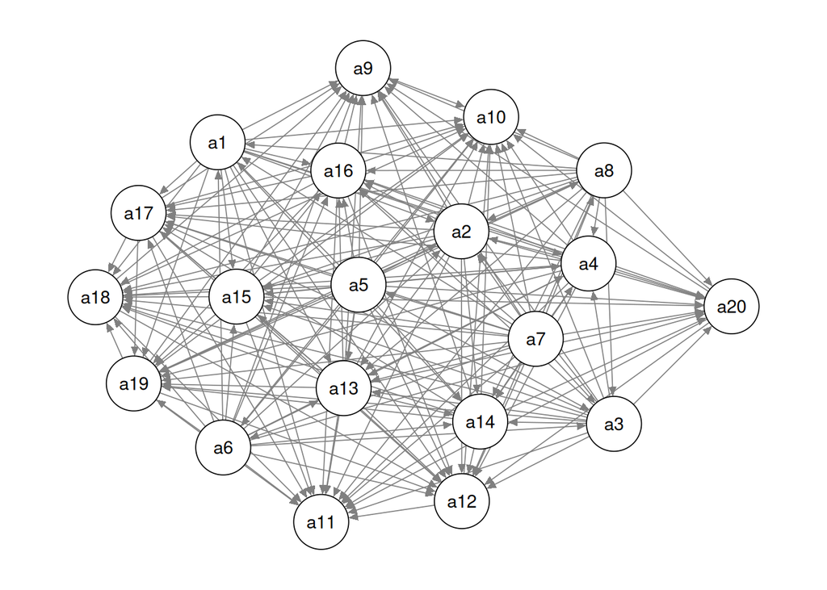

```r
library(qgraph)
qgraph::qgraph(resultados_electre$relacion.dominante)
```

## Métodos PROMETHEE I y II

PROMETHEE I clasifica las alternativas utilizando flujos de preferencia entrantes y salientes. PROMETHEE II extiende este análisis calculando flujos netos para obtener un ranking completo de las alternativas.

```r
## PROMETHEE I y II: Implementación en el análisis

# Definir pesos obtenidos con AHP
pesos_criterios <- c(
  Promedio_D_Score = ahp_weights["Promedio_D_Score"],
  Promedio_E_Score = ahp_weights["Promedio_E_Score"],
  Promedio_Penalty = ahp_weights["Promedio_Penalty"],
  Importancia_Media_Competencia = ahp_weights["Importancia_Media_Competencia"],
  Importancia_Media_Ronda = ahp_weights["Importancia_Media_Ronda"]
)

# Crear una tabla de funciones de preferencia
tab_fpref <- data.frame(
  tipo = c(5, 5, 1, 5, 5),  # Usual solo para penalty, otros lineales
  qi = c(0.1, 0.05, 0, 0.1, 0.2),    # Umbral de indiferencia (no aplicable para función lineal y usual)
  pi = c(0.1, 0.05, 0, 0.1, 0.2),    # Umbral de preferencia
  si = c(0, 0, 0, 0, 0)     # No aplicable para función usual y lineal
)

rownames(tab_fpref) <- names(pesos_criterios)

# Aplicar el método PROMETHEE I
resultado_promethee_i <- multicriterio.metodo.promethee_i(
  tabdecs.X = matriz_homogeneizada,
  pesos.criterios = ahp_weights,
  tab.fpref = tab_fpref
)

# Mostrar resultados de PROMETHEE I
print("Flujos entrantes (Promethee I):")
```

```
## [1] "Flujos entrantes (Promethee I):"
```

```r
print(resultado_promethee_i$vflujos.ent)
```

```
##         a1         a2         a3         a4         a5         a6         a7
## 12.0208890 10.9797445 12.0608040 11.9862977 16.3672076 16.0000000 16.5508114
##         a8         a9        a10        a11        a12        a13        a14
## 16.1836038  0.1836038  0.0000000  0.3672076  0.5508114  8.8704842  8.0000000
##        a15        a16        a17        a18        a19        a20
##  8.6868804  7.9654087  4.8438384  2.6331003  4.9183447  4.0554803
```

```r
print("Flujos salientes (Promethee I):")
```

```
## [1] "Flujos salientes (Promethee I):"
```

```r
print(resultado_promethee_i$vflujos.sal)
```

```
##         a1         a2         a3         a4         a5         a6         a7
##  4.3672076  4.5508114  4.1090975  4.1836038  0.1836038  0.5508114  0.0000000
##         a8         a9        a10        a11        a12        a13        a14
##  0.3672076 15.7757225 15.9593263 15.5921187 15.4085149  7.4008951  7.8502288
##        a15        a16        a17        a18        a19        a20
##  7.9117915  8.7423607 12.1836038 13.1156507 12.2181951 12.7537669
```

```r
print("Relación de superación (Promethee I):")
```

```
## [1] "Relación de superación (Promethee I):"
```

```r
print(resultado_promethee_i$tablarelacionsupera)
```

```
##      a1  a2  a3  a4  a5  a6  a7  a8  a9 a10 a11 a12 a13 a14 a15 a16 a17 a18 a19
## a1  0.5 1.0 0.0 0.0 0.0 0.0 0.0 0.0 1.0 1.0 1.0 1.0 1.0 1.0 1.0 1.0 1.0 1.0 1.0
## a2  0.0 0.5 0.0 0.0 0.0 0.0 0.0 0.0 1.0 1.0 1.0 1.0 1.0 1.0 1.0 1.0 1.0 1.0 1.0
## a3  1.0 1.0 0.5 1.0 0.0 0.0 0.0 0.0 1.0 1.0 1.0 1.0 1.0 1.0 1.0 1.0 1.0 1.0 1.0
## a4  0.0 1.0 0.0 0.5 0.0 0.0 0.0 0.0 1.0 1.0 1.0 1.0 1.0 1.0 1.0 1.0 1.0 1.0 1.0
## a5  1.0 1.0 1.0 1.0 0.5 1.0 0.0 1.0 1.0 1.0 1.0 1.0 1.0 1.0 1.0 1.0 1.0 1.0 1.0
## a6  1.0 1.0 1.0 1.0 0.0 0.5 0.0 0.0 1.0 1.0 1.0 1.0 1.0 1.0 1.0 1.0 1.0 1.0 1.0
## a7  1.0 1.0 1.0 1.0 1.0 1.0 0.5 1.0 1.0 1.0 1.0 1.0 1.0 1.0 1.0 1.0 1.0 1.0 1.0
## a8  1.0 1.0 1.0 1.0 0.0 1.0 0.0 0.5 1.0 1.0 1.0 1.0 1.0 1.0 1.0 1.0 1.0 1.0 1.0
## a9  0.0 0.0 0.0 0.0 0.0 0.0 0.0 0.0 0.5 1.0 0.0 0.0 0.0 0.0 0.0 0.0 0.0 0.0 0.0
## a10 0.0 0.0 0.0 0.0 0.0 0.0 0.0 0.0 0.0 0.5 0.0 0.0 0.0 0.0 0.0 0.0 0.0 0.0 0.0
## a11 0.0 0.0 0.0 0.0 0.0 0.0 0.0 0.0 1.0 1.0 0.5 0.0 0.0 0.0 0.0 0.0 0.0 0.0 0.0
## a12 0.0 0.0 0.0 0.0 0.0 0.0 0.0 0.0 1.0 1.0 1.0 0.5 0.0 0.0 0.0 0.0 0.0 0.0 0.0
## a13 0.0 0.0 0.0 0.0 0.0 0.0 0.0 0.0 1.0 1.0 1.0 1.0 0.5 1.0 1.0 1.0 1.0 1.0 1.0
## a14 0.0 0.0 0.0 0.0 0.0 0.0 0.0 0.0 1.0 1.0 1.0 1.0 0.0 0.5 0.0 1.0 1.0 1.0 1.0
## a15 0.0 0.0 0.0 0.0 0.0 0.0 0.0 0.0 1.0 1.0 1.0 1.0 0.0 0.0 0.5 1.0 1.0 1.0 1.0
## a16 0.0 0.0 0.0 0.0 0.0 0.0 0.0 0.0 1.0 1.0 1.0 1.0 0.0 0.0 0.0 0.5 1.0 1.0 1.0
## a17 0.0 0.0 0.0 0.0 0.0 0.0 0.0 0.0 1.0 1.0 1.0 1.0 0.0 0.0 0.0 0.0 0.5 1.0 0.0
## a18 0.0 0.0 0.0 0.0 0.0 0.0 0.0 0.0 1.0 1.0 1.0 1.0 0.0 0.0 0.0 0.0 0.0 0.5 0.0
## a19 0.0 0.0 0.0 0.0 0.0 0.0 0.0 0.0 1.0 1.0 1.0 1.0 0.0 0.0 0.0 0.0 0.0 1.0 0.5
## a20 0.0 0.0 0.0 0.0 0.0 0.0 0.0 0.0 1.0 1.0 1.0 1.0 0.0 0.0 0.0 0.0 0.0 1.0 0.0
##     a20
## a1  1.0
## a2  1.0
## a3  1.0
## a4  1.0
## a5  1.0
## a6  1.0
## a7  1.0
## a8  1.0
## a9  0.0
## a10 0.0
## a11 0.0
## a12 0.0
## a13 1.0
## a14 1.0
## a15 1.0
## a16 1.0
## a17 1.0
## a18 0.0
## a19 1.0
## a20 0.5
```

```r
# Aplicar el método PROMETHEE II
resultado_promethee_ii <- multicriterio.metodo.promethee_ii(
  tabdecs.X = matriz_homogeneizada,
  pesos.criterios = ahp_weights,
  tab.fpref = tab_fpref
)

# Mostrar resultados de PROMETHEE II
print("Flujos netos (Promethee II):")
```

```
## [1] "Flujos netos (Promethee II):"
```

```r
print(resultado_promethee_ii$vflujos.netos)
```

```
##          a1          a2          a3          a4          a5          a6
##   7.6536814   6.4289331   7.9517065   7.8026939  16.1836038  15.4491886
##          a7          a8          a9         a10         a11         a12
##  16.5508114  15.8163962 -15.5921187 -15.9593263 -15.2249111 -14.8577035
##         a13         a14         a15         a16         a17         a18
##   1.4695891   0.1497712   0.7750889  -0.7769519  -7.3397654 -10.4825504
##         a19         a20
##  -7.2998504  -8.6982866
```

```r
# Ordenar los países según los flujos netos
ranking_promethee_ii <- sort(resultado_promethee_ii$vflujos.netos, decreasing = TRUE)
print("Ranking según PROMETHEE II:")
```

```
## [1] "Ranking según PROMETHEE II:"
```

```r
print(ranking_promethee_ii)
```

```
##          a7          a5          a8          a6          a3          a4
##  16.5508114  16.1836038  15.8163962  15.4491886   7.9517065   7.8026939
##          a1          a2         a13         a15         a14         a16
##   7.6536814   6.4289331   1.4695891   0.7750889   0.1497712  -0.7769519
##         a19         a17         a20         a18         a12         a11
##  -7.2998504  -7.3397654  -8.6982866 -10.4825504 -14.8577035 -15.2249111
##          a9         a10
## -15.5921187 -15.9593263
```

Para el metodo Promethee 2 en este caso tambien Francia es la mejor alternativa, seguida por España y Gran Bretaña.

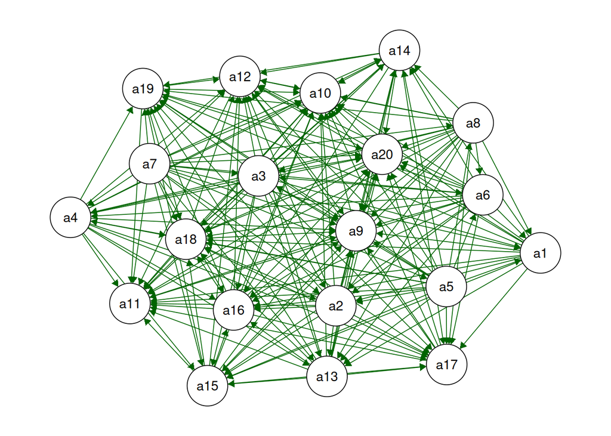

```r
qgraph::qgraph(resultado_promethee_i$tablarelacionsupera)
```

En este caso tambien Francia es la mejor alternativa, seguida por España y Gran Bretaña exactamente como en el metodo Promethee 2, Electre y el ranking de AHP. Entonces se puede concluir que Francia es el mejor pais en la competencia de gimnasia en el periodo 2022-2023 seguido por España y Gran Bretaña seguindo este estudio multicriterio.

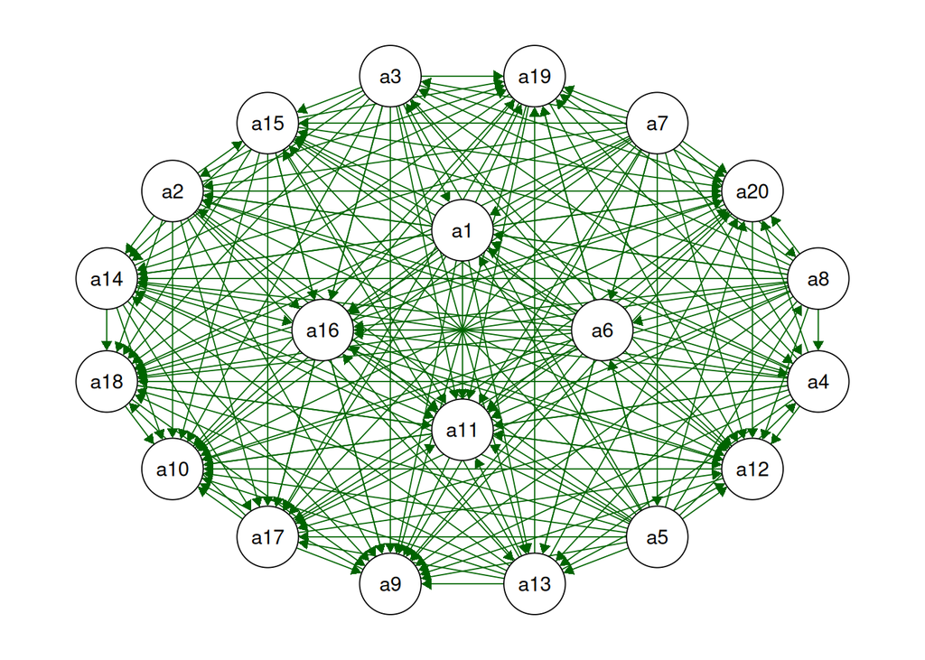

```r
qgraph::qgraph(resultado_promethee_ii$tablarelacionsupera)
```

## Resultados y Conclusiones

Los resultados obtenidos de los métodos multicriterio muestran que Francia es la mejor alternativa en términos de rendimiento general en competencias de gimnasia durante 2022-2023. Este hallazgo es consistente a través de todos los métodos aplicados: AHP, ELECTRE, y PROMETHEE.